# TD: Analyse RNA-Seq sous R/Bioconductor: Visualisation et Enrichissement GO

Ghislain Bidaut, Plateforme Cibi, CRCM, Aix-Marseille Université

Septembre 2024

[figure not shown]

# 1 Visualisation de données RNA-seq sous R/Bioconductor

**Objectif:** Dans le cadre de ce **TD**, nous allons visualiser les données obtenues dans l’analyse différentielle à l’aide de différents outils:

- Heatmaps
- Volcano plots
- Profils d’expression

## 1.1 Chargement des données

Nous allons recharger la librairie `EdgeR`, qui nous a servi à générer les données dans le TD précédent.

**Si besoin**, charger les objets `annotated_expression_counts`, `et`, `targets`, et `y` générés lors du TD précédent.

Copiez ce fichier dans le répertoire courant.

```r
library(edgeR)
load(file = "diffAnalysis.RData")
```

Nous disposons ensuite des objets suivants:

```r
ls()
```

```
## [1] "annotated_expression_counts" "et"
## [3] "show_sol"                    "show_sol_heatmap"
## [5] "targets"                     "y"
```

## 1.2 Génération d’une heatmap (diagramme de chaleur)

Une heatmap est une représentation matricielle des données. Typiquement, nous représentations les profils d’expression des gènes **en ligne** et les échantillons **en colonnes**. Les valeurs de comptages sont représentées sous la forme d’une couleur adaptée.

Sous Bioconductor, nous disposons du package `pheatmap`.

## 1.3 Heatmap des gènes les plus significativement exprimés

Chargement des packages: `pheatmap`pour la représentation de données et `RcolorBrewer` pour les palettes de couleurs.

```r
library(pheatmap)
library(RColorBrewer)
```

On extrait les valeurs d’expression de l’objet `y` par la fonction `cpm`.

```r
expres <- cpm(y, log= TRUE)
```

Nous préparons deux variables: L’une est une palette de couleurs `colors` à l’aide de la fonction `colorRampPalette`. L’autre est un tableau `sample_annot` contenant les annotations des échantillons que l’on souhaite afficher sur la heatmap.

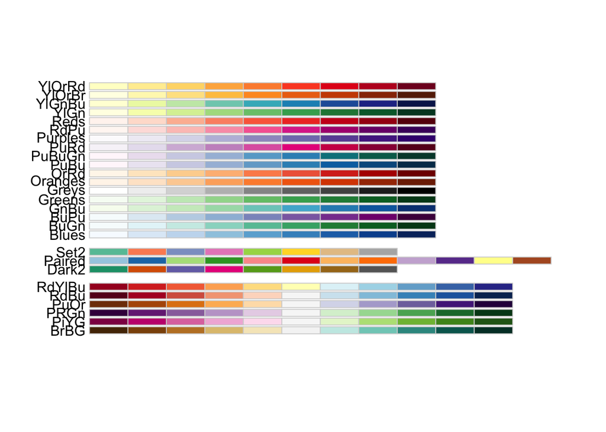

```r
# Couleur Rouge-> Bleue, puis on applique une inversion
colors <- rev(colorRampPalette(brewer.pal(10, "RdBu"))(256))

# Pour voir l'ensemble des couleurs disponibles et compatibles avec les daltoniens, on peut faire un

display.brewer.all(colorblindFriendly = TRUE)
```

```r
# (Voir site https://www.datanovia.com/en/fr/blog/palette-de-couleurs-rcolorbrewer-de-a-a-z/)

sample_annot <- data.frame(Treatment=targets$Treatment, Batch=paste("Batch", targets$Sample), row.names = targets$SRA_ID)

sample_annot
```

```
##            Treatment   Batch
## SRR9005674      THP0 Batch 1
## SRR9005675      THP0 Batch 2
## SRR9005676      THP0 Batch 3
## SRR9005677         M Batch 1
## SRR9005678         M Batch 2
## SRR9005679         M Batch 3
```

Nous extrayons les gènes les plus significativement exprimés du test fait avec **EdgeR** dans le TP précédent.

Le résultat du test est stocké dans l’objet `et`. Nous l’extrayons avec `topTags`.

```r
tt <- topTags(et, adjust.method = "BH", sort.by = c("PValue"), n=20000)
colnames(tt)
```

```
##  [1] "ensembl_gene_id_version" "entrezgene_id"
##  [3] "hgnc_symbol"             "Chr"
##  [5] "Start"                   "End"
##  [7] "Strand"                  "Length"
##  [9] "logFC"                   "logCPM"
## [11] "PValue"                  "FDR"
```

La table tt (topTags) contient les statistiques associées à l’analyse différentielle des gènes. Nous pouvons trouver les gènes significativement différentiellement exprimés, en appliquant un seuil $alpha$ sur la p-valeur **ajustee** et un seuil $logFC.th$ sur la valeur logFC (Log Fold change). Nous Appliquons un seuil sur la **valeur absolue** de logFC de manière à extraire les gènes **sur-** et **sous-** exprimés.

```r
logFC.th = 2.0
alpha = 1e-80

tt_selected <- tt[abs(tt$table$logFC) >= logFC.th & tt$table$FDR <= alpha,]

significant.genes <- rownames(tt_selected)
head(significant.genes)
```

```
## [1] "6299"  "7268"  "17946" "17897" "4241"  "4289"
```

```r
selected_gene_count <- expres[significant.genes, ]

selected_gene_annot <- y$genes[significant.genes, ]

row.names(selected_gene_count) <- paste(selected_gene_annot$ensembl_gene_id_version,  '[', selected_gene_annot$hgnc_symbol , ']')

labels_cols <- paste(targets$SRA_ID,  '[',  targets$Treatment, ']')
```

### 1.3.1 TD:

Réutiliser l’objet `sample_annot` défini précédemment puis faire appel à `pheatmap` avec les données présentes dans `selected_gene_count`.

### 1.3.2 Solution:

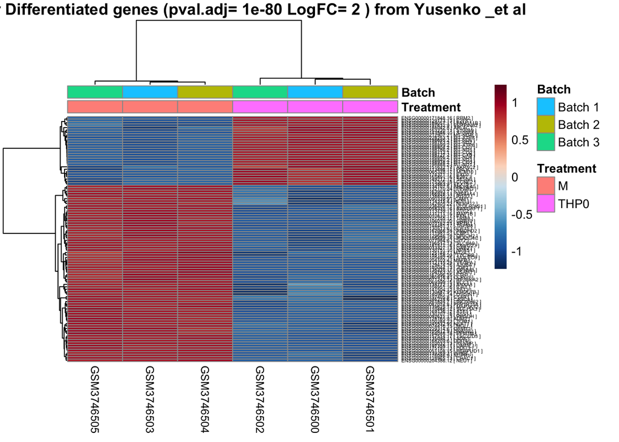

```r
pheatmap(selected_gene_count, cluster_rows = T, cluster_cols = T, scale = "row", main = paste("TMM for Differentiated genes (pval.adj=", alpha, "LogFC=", logFC.th, ") from Yusenko _et al"), fontsize_row = 4, annotation_col = sample_annot, fontsize_col = 9, labels_col = as.character(targets$GEO_ID), color = colors, height = 20)
```

## 1.4 Représentation des gènes significativement et différentiellement exprimés sous forme de diagramme en volcan ( *volcano plot* )

Un *volcano plot* consiste à représenter le nuage de points défini par $(x,y) = (logFC(g) , -log_{10} (pVal(g))$, $logFC(g)$ étant la valeur log Fold-Change associé au gène $g$ entre les deux conditions comparées, et $pVal.adj(g)$ étant la p-valeur **ajustée** associée au test statistique utilisé.

Nous utilisons la fonction `densCols` qui permet d’encoder la densité locale des points à représenter avec une couleur.

```r
cols <- densCols(tt$table$logFC,
                 -log10(tt$table$FDR),
                 colramp = colorRampPalette("grey"))
```

Ensuite, nous faisons appel à la fonction `plot` avec les couleurs calculées précédemment.

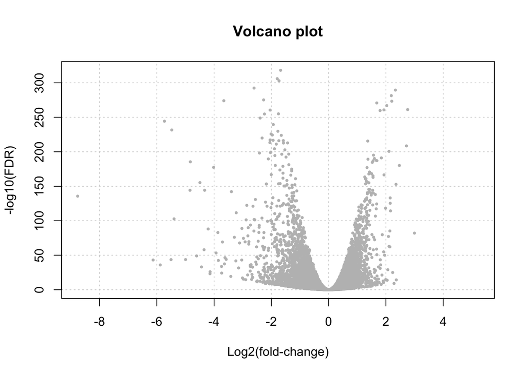

```r
plot(tt$table$logFC,
     -log10(tt$table$FDR),
     col=cols, panel.first=grid(),
     main="Volcano plot",
     xlab="Log2(fold-change)",
     ylab="-log10(FDR)",
     pch=20, cex=0.6)
```

Nous avons maintenant l’ensemble du nuage.

### 1.4.1 TD:

1. Matérialiser les valeurs seuils $logFC.th$ et $alpha$ appliquées respectivement à $logFC(g)$ et $FDR(g)$ avec des lignes verticales et horizontales.
2. Sélectionner le **sous-ensemble** des données correspondants aux gènes **significativement surexprimés**, c’est à dire avec des $logFC$ et $p-val.adj$ ajustées supérieurs aux seuils $alpha$ et $logFC.th$, et les **afficher en rouge** .

Indice: appliquer la fonction `points` sur ces données grâce à la fonction `with`.

3. Appliquer le même type de sélection pour les gènes **significativement sous-exprimés**. cette fois ci, on appliquera une **couleur verte** aux données.
4. Ajouter **les labels** des gènes les plus différentiellement exprimés.

### 1.4.2 Solution:

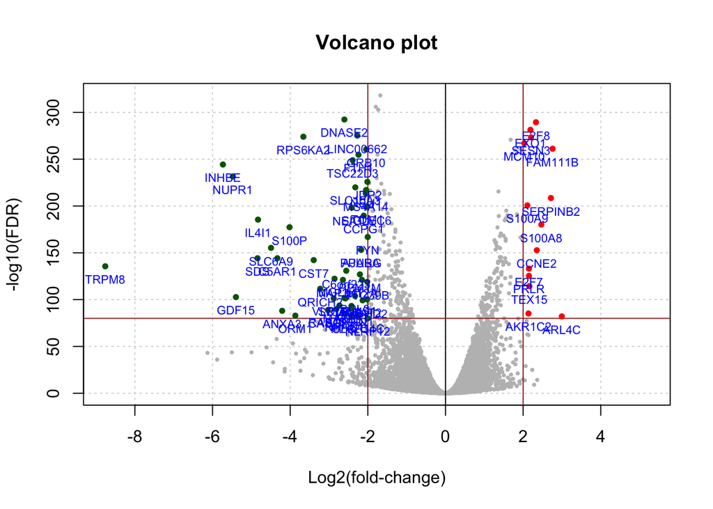

```r
plot(tt$table$logFC,
     -log10(tt$table$FDR),
     col=cols, panel.first=grid(),
     main="Volcano plot",
     xlab="Log2(fold-change)",
     ylab="-log10(FDR)",
     pch=20, cex=0.6)

abline(v=0)
abline(v=c(-logFC.th, logFC.th), col="brown")
abline(h=-log10(alpha), col="brown")

with(subset(tt$table, logFC >= logFC.th & FDR < alpha ),
     points(logFC, -log10(FDR),
            pch=20,
            col="red"))

with(subset(tt$table, logFC <= -logFC.th & FDR < alpha ),
     points(logFC, -log10(FDR),
            pch=20,
            col="darkgreen"))

sub_tt <- subset(tt$table, abs(logFC) >= logFC.th & FDR < alpha )

text(sub_tt$logFC, -log10(sub_tt$FDR),
          labels = sub_tt$hgnc_symbol,
          pos=1, offset = 0.5, cex=0.7,
          col="blue")
```

## 1.5 Représentation interactive de profils d’expression par Glimma

Pour cette partie, nous allons utiliser le package Glimma.

http://bioconductor.org/packages/release/bioc/html/Glimma.html

Et nous documenter avec sa vignette:

https://bioconductor.riken.jp/packages/3.8/bioc/vignettes/Glimma/inst/doc/Glimma.pdf.

C’est un package très intéressant car il permet d’afficher les plots MDS et les profils d’expression de manière interactive et donc d’explorer les données très en profondeur.

### 1.5.1 TD:

1. Installer/charger le package **Glimma**. Parcourir sa documentation.
2. Faire un plot **MDS**. Que peut-on en dire ?
3. Faire un plot des gènes à l’aide de la fonction `glMDPlot`. Sortez les gènes les plus différentiellement exprimés. Comparez au résultat donné par EdgeR.

### 1.5.2 Solution:

```r
# On commence par charger le package

library(Glimma)

# Plot MDS avec GLimma:

glMDSPlot(y, groups =  targets$Treatment)


# Exploration des profils d'expression avec Glimma:

dt.edger <- decideTestsDGE(et)

glMDPlot(et, status=dt.edger, counts=y, groups = targets$Treatment, transform = TRUE, display.columns = c("hgnc_symbol", "entrezgene_id"))
```

# 2 Analyse d’enrichissement GO sous Bioconductor

Nous finissions ce TD par la recherche de pathways différentiellement exprimés. Pour cela , nous allons utiliser le package `ClusterProfiler`.

https://bioconductor.org/packages/release/bioc/html/clusterProfiler.html

Et un tutoriel intéressant:

https://learn.gencore.bio.nyu.edu/rna-seq-analysis/over-representation-analysis/

L’analyse de pathways passe par l’utilisation d’une ontologie dédiée, c’est à dire un vocabulaire contrôlé hiérarchique permettant l’annotation normalisée des gènes. L’ontologie la plus utilis&é est celle établie par le Gene Ontology Consortium, dont les détails sont disponibles sur ce site: http://geneontology.org.

## 2.1 Mise en place des données

Commençons par charger le package:

```r
library(clusterProfiler)
```

Nous travaillons dans l’humain, et devons donc charger la base de données correspondante. Les annotations disponibles sont listées ici: http://bioconductor.org/packages/release/BiocViews.html#___OrgDb.

```r
organism = "org.Hs.eg.db"

# Eventuellement l'installer:
#BiocManager::install(organism, character.only = TRUE)

library(organism, character.only = TRUE)
```

Ensuite, nous allons analyser les pathways pour les gènes les plus différentiellement exprimés et su-exprimés dans la condition *M* vs *TH0* (donc vérifiant $logFC > 0$).

Pour cela, nous devons extraire cette liste sous forme d’identifiants de gènes, à partir de la table `tt`. La fonction `subset` fera l’affaire.

```r
sub_tt <- base::subset(tt$table, logFC >= logFC.th & FDR < 1e-3 )

gene_names <- sub_tt$entrezgene_id
```

### 2.1.1 TD:

Créer l’objet EnrichGO en spécifiant que nous disposons d’une liste sous la forme d’identifiant de type **Entrez Gene ID** et que nous souhaitons extraire les *Biological Pathways*.

### 2.1.2 Solution:

```r
go_enrich <- enrichGO(gene = gene_names,
                      OrgDb = organism,
                      keyType = 'ENTREZID',
                      readable = T,
                      ont = "BP",  # Biological process
                      pvalueCutoff = 0.05,
                      qvalueCutoff = 0.10)
```

## 2.2 Représentation graphique

### 2.2.1 TD:

1. Afficher les *Biological Pathways* par exemple les 10 les plus différentiellement exprimés, à l’aide de `barplot`.
2. Utiliser l’outil `dotplot`.
3. Sous forme de *Data Frame*.

### 2.2.2 Solution:

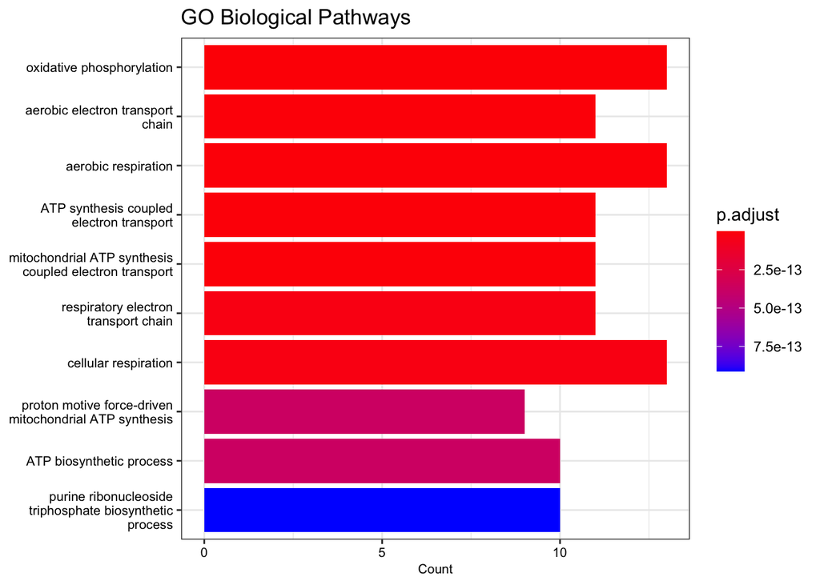

```r
# Par barplot
barplot(go_enrich,
        drop = TRUE,
        showCategory = 10,
        title = "GO Biological Pathways",
        font.size = 8)
```

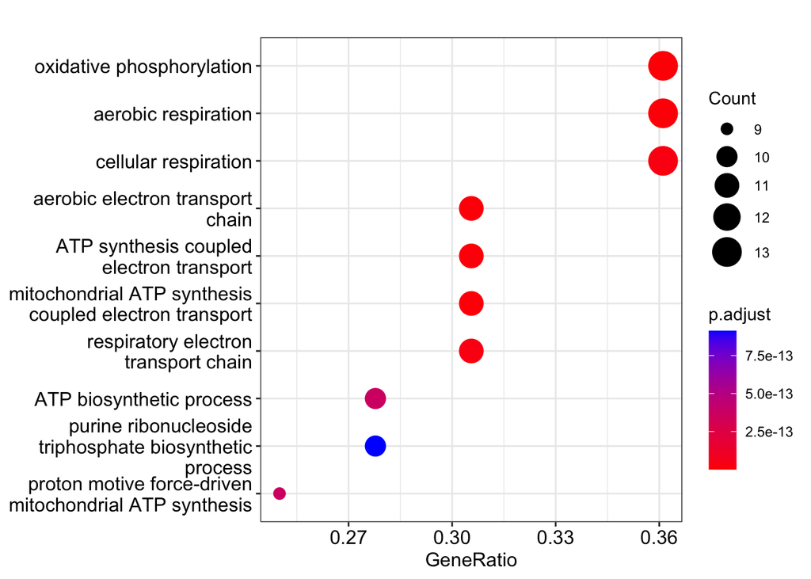

```r
# Par DotPlot:

dotplot(go_enrich)
```

```r
# Sous forme de table

head(data.frame(go_enrich))
```

```
##                    ID                                            Description
## GO:0006119 GO:0006119                              oxidative phosphorylation
## GO:0019646 GO:0019646                       aerobic electron transport chain
## GO:0009060 GO:0009060                                    aerobic respiration
## GO:0042773 GO:0042773               ATP synthesis coupled electron transport
## GO:0042775 GO:0042775 mitochondrial ATP synthesis coupled electron transport
## GO:0022904 GO:0022904                   respiratory electron transport chain
##            GeneRatio   BgRatio       pvalue     p.adjust       qvalue
## GO:0006119     13/36 147/18903 4.390235e-19 3.310238e-16 2.463153e-16
## GO:0019646     11/36  93/18903 1.205272e-17 4.411257e-15 3.282423e-15
## GO:0009060     13/36 194/18903 1.755142e-17 4.411257e-15 3.282423e-15
## GO:0042773     11/36 101/18903 3.111869e-17 4.692699e-15 3.491845e-15
## GO:0042775     11/36 101/18903 3.111869e-17 4.692699e-15 3.491845e-15
## GO:0022904     11/36 122/18903 2.678033e-16 3.089833e-14 2.299150e-14
##                                                                geneID Count
## GO:0006119 COX1/COX2/ND4/ND4L/COX3/ND6/ND3/ATP8/ATP6/ND5/CYTB/ND1/ND2    13
## GO:0019646           COX1/COX2/ND4/ND4L/COX3/ND6/ND3/ND5/CYTB/ND1/ND2    11
## GO:0009060 COX1/COX2/ND4/ND4L/COX3/ND6/ND3/ATP8/ATP6/ND5/CYTB/ND1/ND2    13
## GO:0042773           COX1/COX2/ND4/ND4L/COX3/ND6/ND3/ND5/CYTB/ND1/ND2    11
## GO:0042775           COX1/COX2/ND4/ND4L/COX3/ND6/ND3/ND5/CYTB/ND1/ND2    11
## GO:0022904           COX1/COX2/ND4/ND4L/COX3/ND6/ND3/ND5/CYTB/ND1/ND2    11
```

Cette œuvre est mise à disposition selon les termes de la [Licence Creative Commons:](http://creativecommons.org/licenses/by-nc-nd/4.0/)  
Attribution - Pas d’Utilisation Commerciale - Pas de Modification 4.0 International (CC BY-NC-ND 4.0).